# 관계형 데이터베이스

인간이 생각하는 개념 또는 정보의 세계에서는 의미있는 정보의 단위를 **엔티티(entity)** 를 관계형 데이터베이스는 테이블(table)로 표현한다. 각 행은 레코드라고 불리며 엔티티의 인스턴스(instance)가 되며, 각 칼럼은 속성(attribute)에 대한 정보가 담겨진다. 테이블은 유일무이한 키(unique key)로 연결되어 있고, SQL(Structured Query Language)를 이용하여 데이터베이스와 상호작용하게 된다.

[figure not shown]

## Sqlite

관계형 데이터베이스에 데이터를 관리하게 되면 후속 데이터 분석과정에서 발생할 수 있는 다양한 문제를 미연에 방지할 수 있고, 무엇보다 대용량의 데이터를 필요할 때마다 접속해서 가져온다는 측면에서 편리하다. 관계형 데이터베이스에는 마이크로소프트 MS SQL, 오라클, PostreSQL, MySQL, Sqlite 등이 있는데 Sqlite는 로컬 컴퓨터에 파일 형태로 존재해서 사용이 단순하다는 측면에서 편리하다. [SQLite](https://www.sqlite.org/index.html)에 대한 자세한 사항은 웹사이트를 참조한다.

## 데이터베이스와 SQL

데이터베이스에 데이터가 테이블 형태로 서로 유기적으로 잘 연결되어 정리되어 있는 상태에서 SQL 쿼리를 사용해서 원하는 데이터를 가져오거나 변경을 가할 수 있다. 이는 크게 두가지 단계로 나눠진다.

1. 데이터베이스에 연결
2. 쿼리를 데이터베이스에 전달

## 파이썬 판다스

[figure not shown]

# 소프트웨어 카펜트리 - `survey.db`

R과 SQL - 소프트웨어 카펜트리 수업에서 제작한 `survey.db` SQLite 데이터베이스를 파이썬 데이터분석 작업흐름에 추출하여 기본적인 통계분석작업을 수행해 본다.

```python
import pandas as pd
from sqlalchemy import create_engine

# SQL 엔진 연결
sql_engine = create_engine("sqlite:///data/survey.db")

# SQL 엔진을 통해 테이블 가져오기
person = pd.read_sql("Person", sql_engine)

print(person)
```

```
      ident   personal    family
0      dyer    William      Dyer
1        pb      Frank   Pabodie
2      lake   Anderson      Lake
3       roe  Valentina   Roerich
4  danforth      Frank  Danforth
```

# SQL 쿼리 작업

앞서 `sql_engine`을 통해 데이터베이스 연결작업이 완료되면, 다음 단계로 `pd.read_sql()` 메쏘드 내부에 SQL 쿼리를 작성해서 원하는 결과를 데이터프레임으로 가져오는 작업을 수행한다.

```python
query = '''
SELECT *
FROM Survey
WHERE person='lake'
  OR  person='roe';
'''

# SQL 엔진을 통해 테이블 가져오기
lake_roe = pd.read_sql(query, sql_engine)

print(lake_roe)
```

```
   taken person quant  reading
0    734   lake   sal     0.05
1    751   lake   sal     0.10
2    752   lake   rad     2.19
3    752   lake   sal     0.09
4    752   lake  temp   -16.00
5    752    roe   sal    41.60
6    837   lake   rad     1.46
7    837   lake   sal     0.21
8    837    roe   sal    22.50
9    844    roe   rad    11.25
```

# 테이블 병합

`Site` 테이블과 `Visited` 테이블을 결합시켜 새로운 판다스 데이터프레임을 생성시킬 수 있다.

```python
query_join = '''
SELECT Site.lat, Site.long, Visited.dated, Survey.quant, Survey.reading
FROM   Site join Visited
JOIN   Survey
ON     Site.name=Visited.site
  AND  Visited.ident=Survey.taken
  AND  Visited.dated is not null;
'''

# SQL 엔진을 통해 테이블 가져오기
survey_df = pd.read_sql(query_join, sql_engine)

print(survey_df)
```

```
      lat    long       dated quant  reading
0  -49.85 -128.57  1927-02-08   rad     9.82
1  -49.85 -128.57  1927-02-08   sal     0.13
2  -49.85 -128.57  1927-02-10   rad     7.80
3  -49.85 -128.57  1927-02-10   sal     0.09
4  -47.15 -126.72  1939-01-07   rad     8.41
5  -47.15 -126.72  1939-01-07   sal     0.05
6  -47.15 -126.72  1939-01-07  temp   -21.50
7  -47.15 -126.72  1930-01-12   rad     7.22
8  -47.15 -126.72  1930-01-12   sal     0.06
9  -47.15 -126.72  1930-01-12  temp   -26.00
10 -47.15 -126.72  1930-02-26   rad     4.35
11 -47.15 -126.72  1930-02-26   sal     0.10
12 -47.15 -126.72  1930-02-26  temp   -18.50
13 -48.87 -123.40  1932-01-14   rad     1.46
14 -48.87 -123.40  1932-01-14   sal     0.21
15 -48.87 -123.40  1932-01-14   sal    22.50
16 -49.85 -128.57  1932-03-22   rad    11.25
```

# 시각화

판다스 데이터프레임으로 만들어지면 다음 단계로 시각화도 가능하다. `! pip install seaborn` 명령어를 실행하여 다양한 시각화 라이브러리 중 `seaborn`을 사용해서 시각화에 도전해 본다.

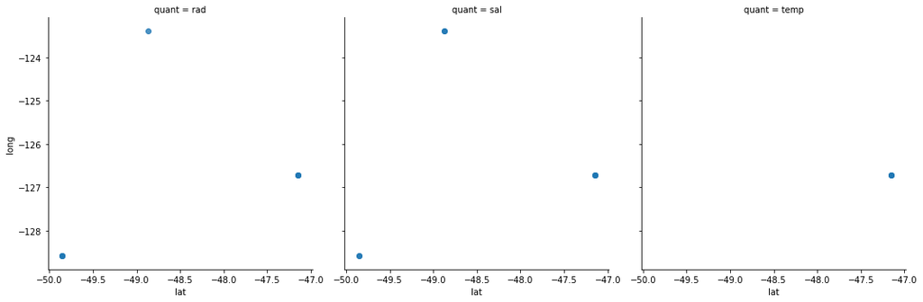

```python
%matplotlib inline

import seaborn as sns

survey_df['reading'] = pd.to_numeric(survey_df['reading'])

sns.lmplot("lat", "long", data=survey_df, fit_reg=False, col='quant')
```